# 6-MRA_Further Issues

Author

Rick Dean

Abstract

The following notes and scripts are based on the following sources: [Introductory Econometrics - A Modern Approach](https://www.amazon.com/Introductory-Econometrics-Modern-Approach-Standalone/dp/130527010X/ref=sr_1_2?dchild=1&keywords=Introductory+Econometrics%3A+A+Modern+Approach&qid=1597005903&s=books&sr=1-2) by Jeffrey M. Wooldridge is the main text for the statistical content. This text will be referenced as `(Wooldridge)`. The companion text [Using R for Introductory Econometrics](http://www.urfie.net/index.html) by Florian Heiss provides specific R scripts in support of the main text and the inspiration for my scripts, notes and graphics. I will reference this document as `(Heiss)`. The following is from **Part 1 - Regression Analysis with Cross-Sectional Data, Chapter 6 MRA Further Issues** of `(Heiss)`.

```r
library(data.table)
library(magrittr)
library(wooldridge)
library(ggplot2)
library(RregressPkg)
library(RplotterPkg)
```

# 6 Multiple Regression Analysis: Further Issues

## 6.1 Model Formulae

## 6.2 Prediction

Predicting the value of the response variable $y$ given certain values of the predictors $x_{1}, x_{2} ... x_{k}$.

In this section we will be following `(Wooldridge page 186 Sectiion 6-4)` to incorporate his techniques rather than using `stats::predict()` from R.

### 6.2.1 Confidence intervals for predictions

Given a OLS model:

$\hat{y} = \hat{\beta_{0}} + \hat{\beta_{1}}x_{1} + \hat{\beta_{2}}x_{2} + ... \hat{\beta_{k}}x_{k}$[6.27 Wooldridge page 186]

and specific values for the predictors: $c_{1}, c_{2} ... c_{k}$

We want to measure the uncertainty for the predicted value $\hat{\theta_{0}}$ where:

$\hat{\theta_{0}} = \hat{\beta_{0}} + \hat{\beta_{1}}c_{1} + \hat{\beta_{2}}c_{2} + ... \hat{\beta_{k}}c_{k}$[6.29 Wooldridge page 187]

A `[Wooldridge]` trick is described for estimating a standard error and subsequently a confidence interval for $\hat{\theta_{0}}$ by solving for the intercept $\hat{\beta_{0}}$ in equation [6.29] and plugging it into equation [6.27] to obtain:

$y = \hat{\theta_{0}} + \beta_{1}(x_{1} - c_{1}) + \beta_{2}(x_{2} - c_{2}) + ... + \beta_{k}(x_{k} - c_{k})$[6.30 Wooldridge page 187]

We can now subtract $c_{1}, c_{2} ... c_{k}$ from each of the sampled $x_{1}, x_{2} ... x_{k}$ and perform the OLS estimates on equation [6.30] where $\hat{\theta_{0}}$ is the intercept with an estimated standard error. Finding the standard error will lead us to defining the $t$-statistic based confidence interval.

Task: Find the confidence interval for predicted college GPA (`wooldridge::gpa2`)

1.Compute the OLS for `colgpa ~ sat + hsperc + hsize + hsize^2`:

```r
data("gpa2", package = "wooldridge")
gpa2_ols_lst <- RregressPkg::ols_calc(
  df = gpa2,
  formula_obj = colgpa ~ sat + hsperc + hsize + I(hsize^2)
)
```

2.Show the coefficients and their standard errors:

```r
RplotterPkg::create_table(
  x = gpa2_ols_lst$coef_df,
  container_width_px = 400
)
```

| Coef | Value | SE | t_value | p_Value |
| --- | --- | --- | --- | --- |
| (Intercept) | 1.492652214 | 7.534142e-02 | 19.811840 | 1.585528e-83 |
| sat | 0.001492497 | 6.521336e-05 | 22.886370 | 3.027519e-109 |
| hsperc | -0.013855782 | 5.610052e-04 | -24.698136 | 9.760760e-126 |
| hsize | -0.060881457 | 1.650123e-02 | -3.689509 | 2.275799e-04 |
| I(hsize^2) | 0.005460295 | 2.269848e-03 | 2.405578 | 1.619059e-02 |

3.Assign a specific set of values for the predictors (i.e. $c_{1}, c_{2} ... c_{k}$) and subtract these values from our sample predictors $x_{1}, x_{2} ... x_{k}$:

```r
gpa2_dt <- data.table::as.data.table(gpa2) %>%
.[, .(colgpa = colgpa, sat = sat - 1200, hsperc = hsperc - 30, hsize = hsize - 5)]
head(gpa2_dt)
```

```
   colgpa  sat     hsperc hsize
1:   2.04 -280  10.000000 -4.90
2:   4.00  -30  -9.680851  4.40
3:   1.78 -390   5.294117 -3.81
4:   2.42 -260  14.133099  0.71
5:   2.61  -20  10.186916 -2.86
6:   3.03 -220 -14.701492 -2.32
```

4.Re-compute the OLS estimate on the new set of predictor values:

```r
gpa2_ols_new_lst <- RregressPkg::ols_calc(
  df = gpa2_dt,
  formula_obj = colgpa ~ sat + hsperc + hsize + I(hsize^2)
)
```

5. Show the coefficients and their standard errors:

```r
RplotterPkg::create_table(
  x = gpa2_ols_new_lst$coef_df,
  container_width_px = 400
)
```

| Coef | Value | SE | t_value | p_Value |
| --- | --- | --- | --- | --- |
| (Intercept) | 2.700075482 | 1.987784e-02 | 135.8334366 | 0.000000e+00 |
| sat | 0.001492497 | 6.521336e-05 | 22.8863702 | 3.027519e-109 |
| hsperc | -0.013855782 | 5.610052e-04 | -24.6981355 | 9.760760e-126 |
| hsize | -0.006278506 | 8.600589e-03 | -0.7300088 | 4.654262e-01 |
| I(hsize^2) | 0.005460295 | 2.269848e-03 | 2.4055777 | 1.619059e-02 |

Now that we have the value for $\hat{\theta_{0}}$ (2.70) and its standard error (0.019) we can compute its $t$-statistic based confidence intervals.

6.Compute $\hat{\theta_{0}}$ confidence intervals at the 95% confidence level:

```r
t_val <- stats::qt(0.975, gpa2_ols_new_lst$n -1)
CI_upper <- gpa2_ols_new_lst$coef_vals[["(Intercept)"]] + gpa2_ols_new_lst$coef_se_vals[["(Intercept)"]] * t_val
CI_lower <- gpa2_ols_new_lst$coef_vals[["(Intercept)"]] - gpa2_ols_new_lst$coef_se_vals[["(Intercept)"]] * t_val
```

The upper CI for $\hat{\theta_{0}}$ is 2.7390467

The lower CI for $\hat{\theta_{0}}$ is 2.6611042

Task: Compare the above results with results using R’s `stats::predict()`.

1.Compute the model using `stats::lm()`:

```r
gpa2_lm <- stats::lm(colgpa ~ sat + hsperc + hsize + I(hsize^2), data = gpa2)
gpa2_lm
```

```
Call:
stats::lm(formula = colgpa ~ sat + hsperc + hsize + I(hsize^2),
    data = gpa2)

Coefficients:
(Intercept)          sat       hsperc        hsize   I(hsize^2)
   1.492652     0.001492    -0.013856    -0.060881     0.005460
```

2.Compute point estimate prediction:

```r
c_values <- data.frame(sat = 1200, hsperc = 30, hsize = 5)
theta_0 <- stats::predict(gpa2_lm, c_values)
theta_0
```

```
       1
2.700075
```

3.Compute confidence interval:

```r
ci_theta_0 <- stats::predict(gpa2_lm, c_values, interval = "confidence")
ci_theta_0
```

```
       fit      lwr      upr
1 2.700075 2.661104 2.739047
```

Take Away: The two approaches agree.

### 6.2.2 Prediction Intervals

Confidence intervals reflect the uncertainty about the **expected value** of the response variable given values for the predictors. In predicting an **individual** we have to account for the additional uncertainty regarding the unobserved characteristics reflected by the error term $\mu$.

We now have two sources of variation:

1. The sampling error in estimating the predictor coefficients which we did in equation [6.29] above for $\hat{\theta_{0}}$
2. The variance of the error in the population $\mu$

1.Read the data:

```r
gpa_2_dt <- data.table::as.data.table(wooldridge::gpa2) %>%
.[, .(colgpa, sat, hsperc, hsize)]
```

2.Define the predictor data points to estimate responses:

```r
predictor_vals_df <- data.frame(
  sat = c(1200, 900, 1400),
  hsperc = c(30, 20, 5),
  hsize = c(5, 3, 1)
)
```

3.Call `RregressPkg::ols_intervals()`:

```r
gpa_2_response_df <- RregressPkg::ols_intervals(
  df = gpa_2_dt,
  formula_obj = colgpa ~ sat + hsperc + hsize + I(hsize^2),
  predictor_vals_df = predictor_vals_df,
  confid_level = 0.99
)
```

4.Display the results:

```r
RplotterPkg::create_table(
  x = gpa_2_response_df,
  container_width_px = 400
)
```

| fit | lwr | upr | se |
| --- | --- | --- | --- |
| 2.700075 | 2.648850 | 2.751301 | 0.01987784 |
| 2.425282 | 2.388540 | 2.462025 | 0.01425783 |
| 3.457448 | 3.385572 | 3.529325 | 0.02789125 |

### 6.2.3 Effect plots for nonlinear specifications

Task: Using `RregressPkg::plot_predictor()` plot the effect of predictor variable *rooms* on the response variable *log(price)* in the `wooldridge::hprice2` data set.

1.Read the data:

```r
data("hprice2", package = "wooldridge")

hprice2_dt <- data.table::as.data.table(hprice2) %>%
  .[, .(price, nox, dist, rooms, stratio)]
```

2.Call `RregressPkg::plot_predictor()`:

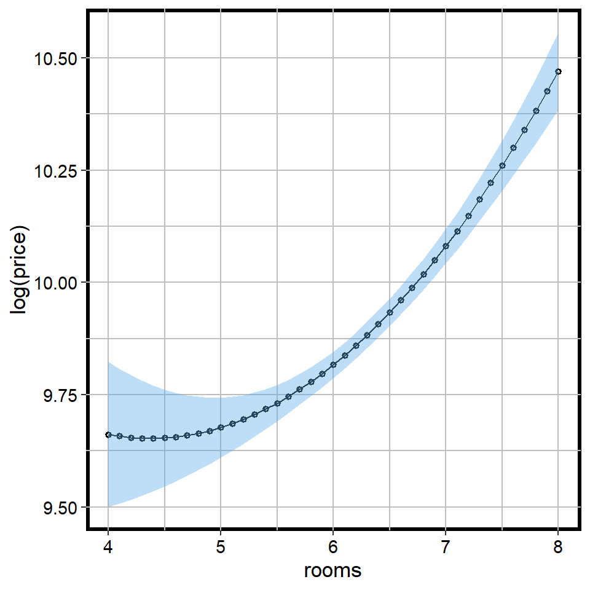

Influence of ‘rooms’ on ‘log(price)’

```r
rooms_effect_lst <- RregressPkg::plot_predictor(
  df = hprice2_dt,
  formula_obj = log(price) ~ log(nox)+log(dist)+rooms+I(rooms^2)+stratio,
  predictor_vals_df = data.frame(rooms = seq(4, 8, 0.1)),
  x_title = "rooms",
  y_title = "log(price)",
  rot_y_tic_label = T
)
rooms_effect_lst$effect_plot
```